# Project Proposal

Author

Alexis Hegarty, Ella Smith, Ashlyn Philips, and Amy Truong

```r
library(tidyverse)
library(broom)

co2 <- read_csv("co2.csv", col_names = TRUE)
cdmt <- read_csv("cdmt.csv", col_names = TRUE)
```

# Part 1: Introduction

### Data Description:

The data we are using in our analysis is sourced from [Gapminder](https://www.gapminder.org/data/documentation/). The Gapminder data sets are compiled of world data ranging from 1800 to 2020. The variables, documented by country (using current geographic boundaries), are indicators of global development and evolution through the past two centuries. Examples of these variables include, child mortality, GDP, fertility rates, life expectancy rates, and more.

The data sets that we will be using in our analysis include two quantitative variables: Carbon Dioxide (CO2) and Child Mortality (CDMT).

The Child Mortality Rate data set combines data from multiple sources to create a data set of child deaths under the age of 5 for each country from 1800 to 2100. Child mortality is measured as the number of 0-5 years dying per 1000 children born. The data set has three variables: country, year, and child mortality rate.

The Carbon Dioxide data set combines data from multiple sources to create a data set of CO2 emissions in tonnes per capita for each country from 1800 to 2022. The data set has three variables: country, year, and CO2 emissions per capita. Both data sets we are using contain from 194 countries.

### Hypothesis

We will use CO2 as our explantory variable and Child mortality as our response varaible.

However, we are also aware that industrialization also could have lowered child mortality rates through the increase in medicine and technology.

### Clean & Merge Data

A glaring factor within the data is the child mortality dataset contains data all the way to 2100. This means the data past 2018 (noted in data description in Gapminder) is predicted. For the purposes of this analysis and the data we have for CO2 emissions, we will only use data from 1800 to 2018.

In our data cleaning process we will omit observations with at least one variable missing. We are aware that omitting these missing variables decreases the sample size and may lead us to miss important information. Since we are using ggplot and lm–which drop missing observations anyway–it makes sense to remove these variables for the entire analysis.

The two data sets will also need to be merged into one data set in long format using the pivot_longer function.

Another important factor to address in our data cleaning process is the different scales the two variables are measured by. “Deaths per 1000 children” is hard to compare in context to “tonnes per capita”. To contextualize the two scales in comparison to each other we will use a log base transformation.

```r
co2_cdmt <- cdmt %>%
  mutate(across(-country, as.character)) %>%
  pivot_longer(cols = -country, names_to = 'year', values_to = 'cdmt') %>%
  mutate(year = as.character(year)) %>%

  full_join(
    co2 %>%
      mutate(across(-country, as.character)) %>%
      pivot_longer(cols = -country, names_to = 'year', values_to = 'co2') %>%
      mutate(year = as.character(year)),
    by = c("country", "year")
  ) %>%

  filter(year < 2018) %>%
  na.omit() %>%
  mutate(year = as.numeric(year),
         co2 = as.numeric(co2),
         cdmt = as.numeric(cdmt)) %>%
  mutate(log_co2 = log(co2)) %>%
  mutate(log_cdmt = log(cdmt))
```

# Part 2: Linear Regression

## Data Visualizations

### Graph: Relationship Observed Over Time

The first data visualization depicts the relationship between the logged values of Co2 emissions and child mortality rates from 1800 to 2018.

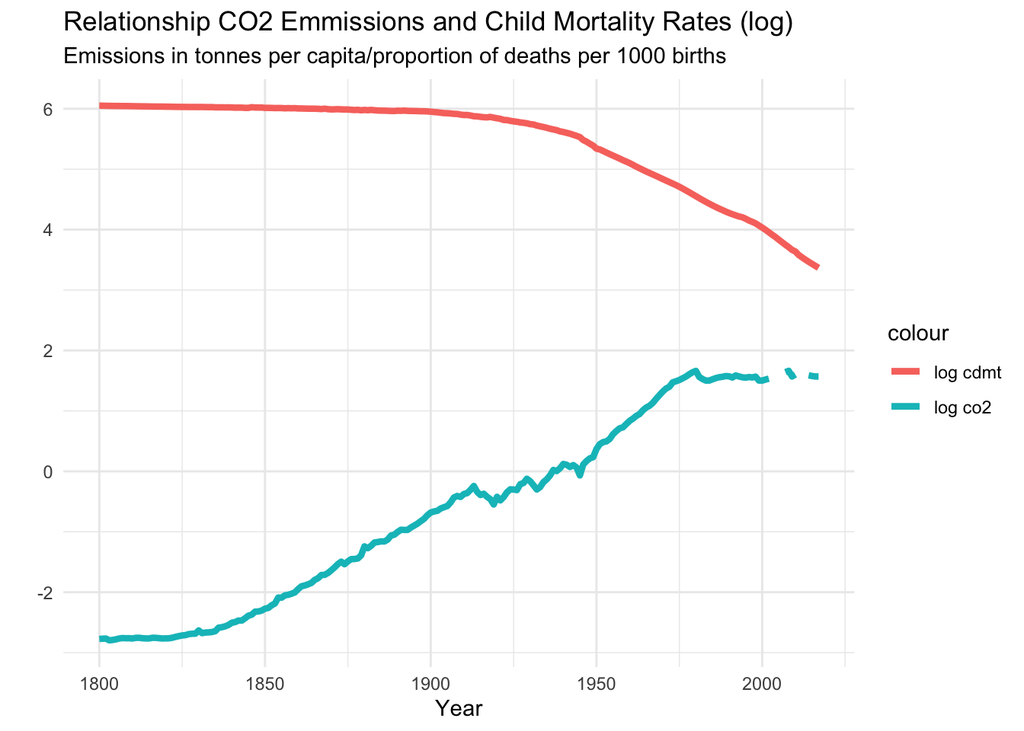

```r
co2_cdmt %>%
  group_by(year) %>%
  summarize(avg_co2 = mean(co2),
            avg_cdmt = mean(cdmt)) %>%

  ggplot(aes(x = year)) +
  geom_line(aes(y = log(avg_co2), color = "log co2"), size = 1.5) +
  geom_line(aes(y = log(avg_cdmt), color = "log cdmt"), size = 1.5) +labs(title = "Relationship CO2 Emmissions and Child Mortality Rates (log)",
       x = "Year",
       y = "", subtitle = "Emissions in tonnes per capita/proportion of deaths per 1000 births") +

  theme_minimal()
```

### Graph: Relationship between CO2 and CDMT

The second visualization is the overall relationship between co2 emissions and child mortality rates by country.

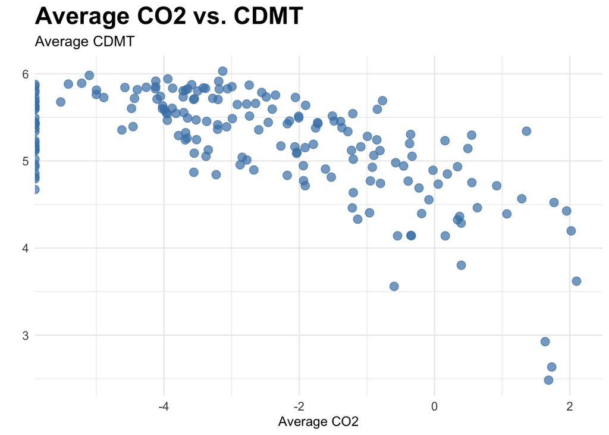

```r
graph<-
co2_cdmt %>%
  group_by(country) %>%
  summarize(log_avg_co2 = mean(log_co2, na.rm = TRUE),
            log_avg_cdmt = mean(log_cdmt, na.rm = TRUE))
graph |>
  ggplot(aes(x = log_avg_co2, y = log_avg_cdmt)) +
  geom_jitter(alpha = 0.7, color = "steelblue", size = 3) +
  labs(title = "Average CO2 vs. CDMT",
       subtitle = "Average CDMT",
       x = "Average CO2",
       y = "") +
  theme_minimal() +
  theme(plot.title = element_text(size = 20, face = "bold"),
        plot.subtitle = element_text(size = 12),
        axis.text = element_text(size = 10))
```

By observing this graph we can infer an important detail about the relationship between average CO2 emissions and average child mortality rate. Each data point represents a country. It seems as there is a negative relationship between the two variables. As co2 increase child mortality rates decrease.

## Linear Regression

The statistical method we are using to analyze the data is linear regression. This model is used to examine the relationship between an independent and dependent variable. In this case, CO2 emissions is the independent variable and child mortality rate is the dependent variable. The linear model assumes these two variables have a linear relationship; the changes in the independent variables are associated with a constant change in the dependent variable. This is the form for our model:

y = intercecpt + slope + error term

Where y represents the dependent variable, child mortality and slope represents in the independent variable, CO2 emissions.

### Graph: Linear Model Visualization

The following graph depicts the visualization of our simple linear regression.

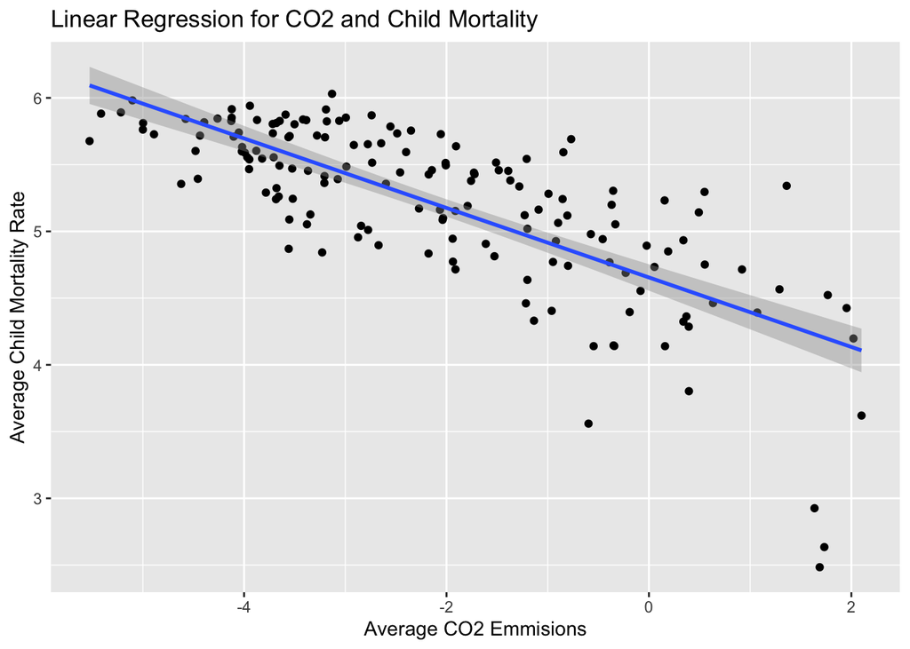

```r
graph <- graph %>%
  filter(log_avg_cdmt != -Inf) %>%
  filter(log_avg_co2 != -Inf)

reg <- lm(log_avg_cdmt~log_avg_co2, data = graph)

graph |>
  ggplot(aes(x=log_avg_co2, y=log_avg_cdmt))+
  geom_jitter()+
  geom_smooth(method = "lm")+
  labs(title = "Linear Regression for CO2 and Child Mortality",
       x = "Average CO2 Emmisions",
       y = "Average Child Mortality Rate")
```

There appears to be a moderate linear negative relationship between the logged average values of co2 and child mortality. There appears to be outliers on the low end and a slight fanning of the points as co2 increases. There does seem to be a moderate linear correlation between the co2 and cdmt.

```r
broom:: tidy(reg)
```

```
# A tibble: 2 × 5
  term        estimate std.error statistic   p.value
  <chr>          <dbl>     <dbl>     <dbl>     <dbl>
1 (Intercept)    4.65     0.0502      92.7 1.10e-139
2 log_avg_co2   -0.260    0.0181     -14.4 1.87e- 30
```

Estimated Regression Model in Context:

Average Child Mortality Rate = 4.65 - 0.26*CO2

## LINE Conditions

### Linearity and Equal Variance

To assess linearity and equal variance we will asses the residual plot.

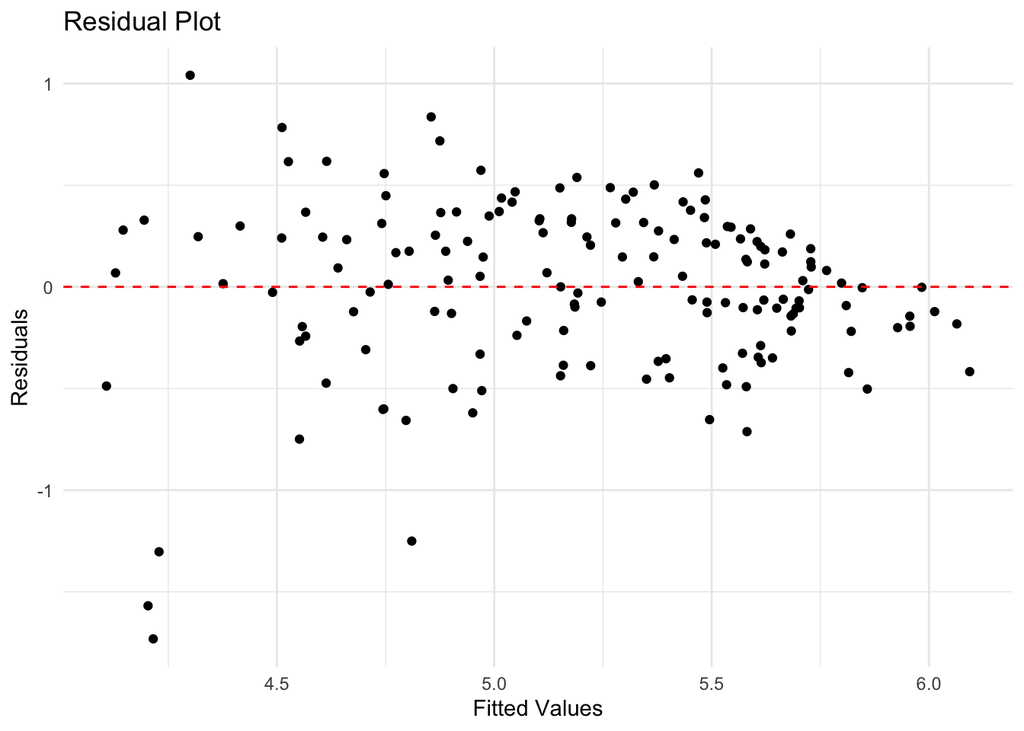

```r
# Get residuals and predicted values
residual <- augment(reg)
residual_for_norm <- reg$residuals
predicted <- predict(reg)

# Create a residual plot
residual_plot <- ggplot(residual, aes(x = .fitted, y = .resid)) +
  geom_point() +
  geom_hline(yintercept = 0, linetype = "dashed", color = "red") +
  labs(title = "Residual Plot",
       x = "Fitted Values",
       y = "Residuals") +
  theme_minimal()
print(residual_plot)
```

In this case we observer no residuals above 2 or below -2y o, which reveals no outliers. This plot conveys a slight funnel shape from left to right, that shows more spread on the left and more cluster on the right. Due to this, we cannot state that linearity or equal variance is met. Based on this, we will proceed with caution when fitting a linear model.

### Normality

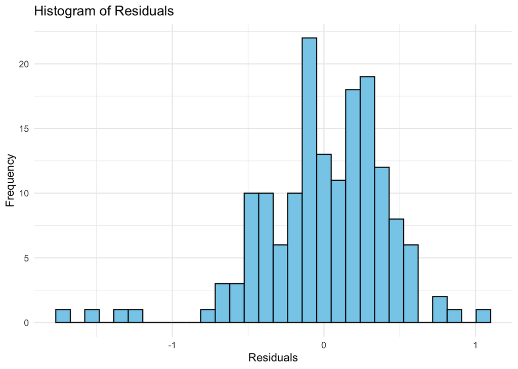

```r
##qqnorm(residual_for_norm, main = "QQPlot of Residuals")
##qqline(residual_for_norm)

ggplot(data = residual, aes(x = .resid)) +
  geom_histogram(fill = "skyblue", color = "black", bins = 30) +
  labs(title = "Histogram of Residuals",
       x = "Residuals",
       y = "Frequency") +
  theme_minimal()
```

### Independence

We do not belive we can assume independence in our data, because Co2 Emission for countries, will likely effect the Co2 emissions of other countries. We think factors like trade and relationships may add confounding variables to our data set.

## Model Fit

```r
response <- graph$log_avg_cdmt
fitted_values <- fitted(reg)
residual_2 <- residuals(reg)

var_response <- var(response)
var_fitted <- var(fitted_values)
var_residuals <- var(residual_2)
Poportion_resid <-var_residuals /var_response
variance_table <- data.frame(
  Variable = c("Response", "Fitted Values", "Residuals", "Proportion"),
  Variance = c(var_response, var_fitted, var_residuals, Poportion_resid)
)
print(variance_table)
```

```
       Variable  Variance
1      Response 0.3962944
2 Fitted Values 0.2243706
3     Residuals 0.1719237
4    Proportion 0.4338283
```

# Part 3: Simulation

## Assessing Predictions

### Visualizing Simulations from the Model

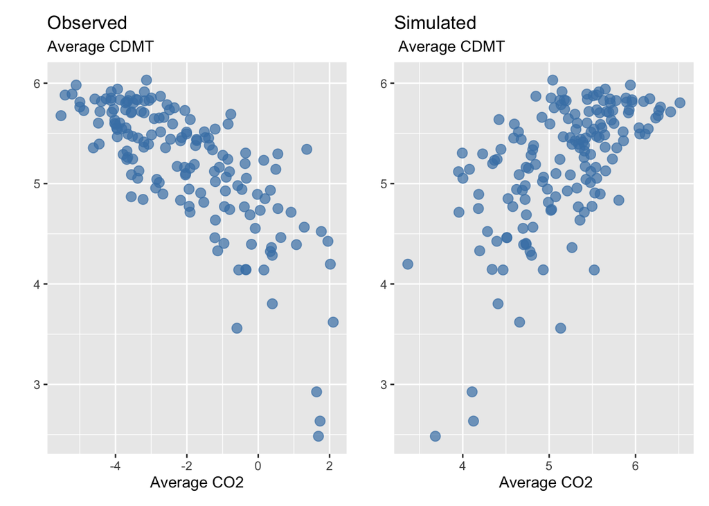

```r
# Get residuals and predicted values
residual <- augment(reg)
predicted <- predict(reg)

# Calculate sigma of residuals from the regression model
co2_cdmt_sigma <- sigma(reg)

# Define noise function to add random noise
noise <- function(x, mean = 0, sd) {
  x + rnorm(length(x), mean, sd)
}

# Simulate response variable using predicted values and sigma of residuals
sim_response <- tibble(sim_cdmt = noise(predicted, sd = co2_cdmt_sigma))

sim_data <- graph |>
  select(log_avg_co2, log_avg_cdmt) |>
  bind_cols(sim_response)


# Plot histograms of observed and simulated response variables
obs_p <- ggplot(data = graph, aes(x = log_avg_co2, y = log_avg_cdmt)) +
  geom_jitter(alpha = 0.7, color = "steelblue", size = 3) +
  labs(title = "Observed",
       subtitle = "Average CDMT",
       x = "Average CO2",
       y = "")

new_p <- ggplot(sim_data, aes(x = sim_cdmt, y = log_avg_cdmt )) +
  geom_jitter(alpha = 0.7, color = "steelblue", size = 3) +
  labs(title = "Simulated", y = "", subtitle = " Average CDMT", x = " Average CO2")

# Combine plots using patchwork
library(patchwork)
obs_p + new_p
```

### Inspect R Squared Values

```r
nsims <- 1000
sims <- map_dfc(.x = 1:nsims,
                .f = ~ tibble(sim = noise(predicted,
                                          sd = co2_cdmt_sigma)
                              )
                )

colnames(sims) <- colnames(sims) |>
  str_replace(pattern = "\\.\\.\\.",
                  replace = "_")

sims <- graph |>
  filter(!is.na(log_avg_co2),
         !is.na(log_avg_cdmt)) |>
  select(log_avg_cdmt) |>
  bind_cols(sims)


sim_r_sq <- sims |>
  map(~ lm(log_avg_cdmt ~ .x, data = sims)) |>
  map(glance) |>
  map_dbl(~ .x$r.squared)

sim_r_sq <- sim_r_sq[names(sim_r_sq) != "log_avg_cdmt"]
```

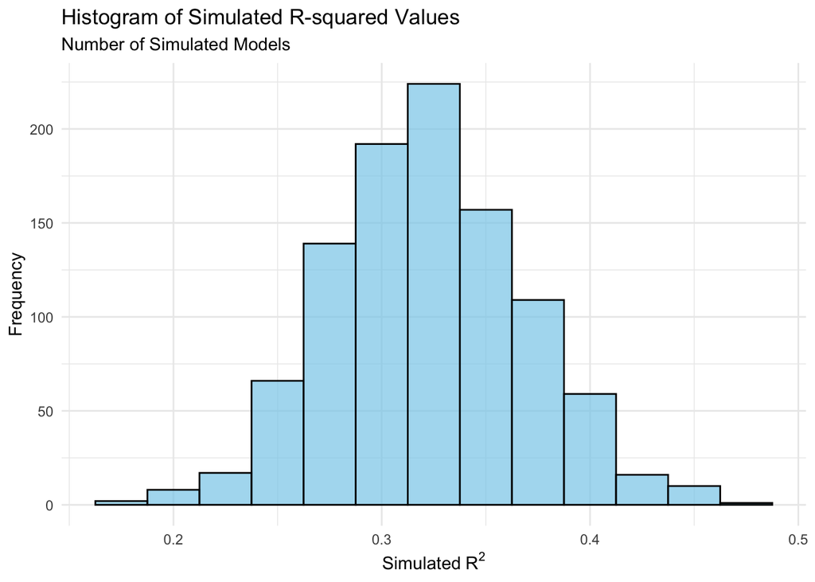

```r
tibble(sims = sim_r_sq) |>
  ggplot(aes(x = sims)) +
  geom_histogram(binwidth = 0.025, fill = "skyblue", color = "black", alpha = 0.7) +
  labs(x = expression("Simulated" ~ R^2),
       y = "Frequency",
       title = "Histogram of Simulated R-squared Values",
       subtitle = "Number of Simulated Models") +
  theme_minimal()
```

This simulated R^2 values seem to be centered around 0.3, with an approximately normal bell shaped curve. This indicates a bad fit, as the values are centered far from 1. Once again, reaffirming our conclusion a linear regression model is not appropriate for our data. In conclusion, C02 Emissions Per Capita is not a good indicator of Child Mortality Rates.